# Homework_Week_1

Question 2.1: Describe a situation or problem from your job, everyday life, current events, etc., for which a classification model would be appropriate. List some (up to 5) predictors that you might use.

Based on some of the common things I do at work (research lab) one classification problem we encounter is predicting deleterious effects of chemical compound concentrations on cell viability.

To classify if a given ligand concentration has a negative effect on cell health we can use the following predictors as clues:

1. Cell morphology: we can measure cell size and granularity (complexity)
2. Duplication rate : the rate at which cells divide and proliferate under these different ligand concentrations
3. Nuclear Fragmentation: Cell damage is correlated with increased nuclear fragmentation
4. Reactive Oxygen Species: ROS within cells can indicate oxidative stress (we use fluorescent dye’s to measure this)
5. Cellular energy : We can monitor cellular ATP levels as a marker for cellular health (low ATP = energy deficiency)

Question 2.2

1. Using the support vector machine function ksvm contained in the R package kernlab, find a good classifier for this data. Show the equation of your classifier, and how well it classifies the data points in the full data set. (Don’t worry about test/validation data yet; we’ll cover that topic soon.)

```r
#install packages
install.packages("kernlab")
install.packages("kknn")
install.packages("caret")
```

```r
library(kknn)
library(kernlab)
library(caret)
library(ggplot2)
```

```r
# Import dataset and check the top
data <- read.csv(file = "credit+approval/credit_card_data-headers.txt", header = TRUE, sep = "")
head(data)
```

|  | A1 | A2 | A3 | A8 | A9 | A10 | A11 | A12 | A14 | A15 | R1 |
| --- | --- | --- | --- | --- | --- | --- | --- | --- | --- | --- | --- |
| 1 | 1 | 30.83 | 0.000 | 1.25 | 1 | 0 | 1 | 1 | 202 | 0 | 1 |
| 2 | 0 | 58.67 | 4.460 | 3.04 | 1 | 0 | 6 | 1 | 43 | 560 | 1 |
| 3 | 0 | 24.50 | 0.500 | 1.50 | 1 | 1 | 0 | 1 | 280 | 824 | 1 |
| 4 | 1 | 27.83 | 1.540 | 3.75 | 1 | 0 | 5 | 0 | 100 | 3 | 1 |
| 5 | 1 | 20.17 | 5.625 | 1.71 | 1 | 1 | 0 | 1 | 120 | 0 | 1 |
| 6 | 1 | 32.08 | 4.000 | 2.50 | 1 | 1 | 0 | 0 | 360 | 0 | 1 |

```r
NA
```

```r
#build SVM model
model <- ksvm(as.matrix(data[,1:10]),as.factor(data[,11]),type= "C-svc",kernel= 'vanilladot' ,C= 5,scaled=TRUE)
model #check out SVM model parameters
```

```
Support Vector Machine object of class "ksvm"

SV type: C-svc  (classification)
 parameter : cost C = 5

Linear (vanilla) kernel function.

Number of Support Vectors : 191

Objective Function Value : -894.8826
Training error : 0.136086
```

```r
# calculate a1...am
a <- colSums(model@xmatrix[[1]] * model@coef[[1]])
a
```

```
           A1            A2            A3            A8            A9           A10
-0.0009059129 -0.0009822588 -0.0016646387  0.0025578654  1.0052684085 -0.0025973024
          A11           A12           A14           A15
-0.0002203001 -0.0003290890 -0.0012589283  0.1064307652
```

```r
# calculate a0
a0 <- -(model@b)
a0
```

```
[1] 0.08162012
```

```r
# see what the model predicts
pred <- predict(model,data[,1:10])
pred
```

```
  [1] 1 1 1 1 1 1 1 1 1 1 0 1 1 0 1 1 1 1 1 1 1 1 1 1 1 1 1 1 1 1 1 1 1 1 1 1 1 1 1 1 1 1 1
 [44] 1 1 1 1 1 0 0 1 1 1 1 1 1 1 1 0 1 1 1 1 1 1 1 1 1 1 1 1 1 1 0 1 1 1 1 1 1 1 1 1 1 1 1
 [87] 1 1 1 1 1 1 1 1 1 1 1 1 1 1 1 1 1 1 1 1 1 1 1 1 1 1 1 1 1 1 1 1 1 1 1 1 1 1 1 1 1 1 1
[130] 1 1 1 1 1 1 1 1 1 1 1 1 1 1 1 1 1 1 1 1 1 1 1 1 1 1 1 1 1 1 1 1 1 1 1 0 1 1 1 1 1 1 1
[173] 1 1 1 1 1 1 1 1 1 1 1 1 1 1 1 1 1 1 1 1 1 1 1 1 1 1 1 1 1 1 1 1 1 1 1 1 1 1 1 1 1 1 1
[216] 1 1 1 1 1 0 1 1 1 1 1 1 1 1 1 1 1 1 1 1 1 1 1 1 1 1 1 1 1 1 0 0 0 0 0 0 0 0 0 0 0 0 0
[259] 1 0 0 0 0 0 0 0 0 1 0 0 0 0 0 0 0 0 0 0 0 0 0 0 0 0 0 0 0 0 0 0 0 0 1 0 0 0 0 0 0 0 0
[302] 0 1 0 1 0 0 0 0 0 1 0 0 0 0 0 0 0 0 0 0 0 0 0 0 0 0 0 0 0 0 1 0 0 0 0 0 0 0 0 0 0 0 0
[345] 0 0 0 0 0 0 0 0 0 0 0 0 0 0 0 0 0 0 0 0 0 0 0 0 0 0 0 0 0 0 0 0 0 0 0 0 0 0 0 0 0 0 0
[388] 0 0 0 0 0 0 0 0 0 0 0 0 0 0 0 0 0 0 0 0 0 0 0 0 0 0 0 0 0 0 0 0 0 0 0 0 0 0 0 0 0 0 0
[431] 0 0 0 0 0 0 0 0 0 0 0 0 0 0 0 0 0 0 0 0 0 0 0 0 0 0 0 0 0 0 0 0 0 0 0 1 1 1 1 1 1 1 1
[474] 1 1 1 1 1 1 1 1 1 1 1 1 1 1 1 1 1 1 1 1 1 1 1 1 1 1 1 1 1 1 1 1 1 1 1 1 1 1 1 1 1 1 1
[517] 1 1 1 1 1 1 1 1 1 1 1 1 1 1 1 1 1 1 1 1 1 1 1 1 1 1 1 1 1 1 1 1 1 1 1 1 1 0 1 1 1 1 1
[560] 1 1 1 1 1 0 1 1 1 1 1 1 0 0 1 0 0 0 0 0 0 0 0 0 0 0 0 0 1 0 0 0 0 0 0 0 0 0 0 0 0 0 0
[603] 0 0 0 0 0 0 0 0 0 0 0 0 0 0 0 0 1 0 0 0 0 0 0 0 0 0 0 0 0 0 0 0 0 0 0 0 0 0 0 0 0 0 0
[646] 0 0 0 0 0 0 0 0 0
Levels: 0 1
```

```r
# see what fraction of the model’s predictions match the actual classification
           sum(pred == data[,11]) / nrow(data)
```

```
[1] 0.8639144
```

Solution:

how well it classifies the data points in the full data set

Accuracy of model : 0.8639144

Training error : 0.136086

Question 2.2.3

3. Using the k-nearest-neighbors classification function kknn contained in the R kknn package, suggest a good value of k, and show how well it classifies that data points in the full data set. Don’t forget to scale the data (scale=TRUE in kknn).

```r
#checking if column 11 is a factor
is.factor(data$R1)
```

```
[1] FALSE
```

```r
#split the data into training and test sets for knn using caret's createDataPartition function

set.seed(100) #for reproducible results

data$R1 <- factor(data$R1, levels = c(0, 1)) #make sure the R1 or response column is a factor with two levels 0,1

trainIndex <- createDataPartition(data$R1,
                                  times=1,
                                  p = .7,    # 70% of the data will be for training, remaining 30% will be for test
                                  list = FALSE)
trainData <- data[trainIndex, ]
testData <- data[-trainIndex, ]
```

```r
# K values to be tested 1 to 100
Kvalues <- 1:100

#Data frame to store the k and accuracy values
results <- data.frame(k = integer (), accuracy = numeric())

# loop to find the best K value and accuracy

for (k in Kvalues) {
  model <- kknn(R1~., trainData,testData, k = k, scale =TRUE, kernel = "rectangular") #keep kernel a simple fraction

  predicted <- predict(model)

  accuracy <- sum(predicted == testData$R1)/ nrow(testData)

  print(paste("K is ", k, "With an accuracy of", accuracy))

  results <- rbind(results,data.frame(k = k, accuracy = accuracy)) #save results as a data frame

}
```

```
[1] "K is  1 With an accuracy of 0.78974358974359"
[1] "K is  2 With an accuracy of 0.78974358974359"
[1] "K is  3 With an accuracy of 0.841025641025641"
[1] "K is  4 With an accuracy of 0.841025641025641"
[1] "K is  5 With an accuracy of 0.866666666666667"
[1] "K is  6 With an accuracy of 0.866666666666667"
[1] "K is  7 With an accuracy of 0.856410256410256"
[1] "K is  8 With an accuracy of 0.856410256410256"
[1] "K is  9 With an accuracy of 0.861538461538462"
[1] "K is  10 With an accuracy of 0.861538461538462"
[1] "K is  11 With an accuracy of 0.841025641025641"
[1] "K is  12 With an accuracy of 0.841025641025641"
[1] "K is  13 With an accuracy of 0.835897435897436"
[1] "K is  14 With an accuracy of 0.835897435897436"
[1] "K is  15 With an accuracy of 0.841025641025641"
```

[output cut: 85 more lines]

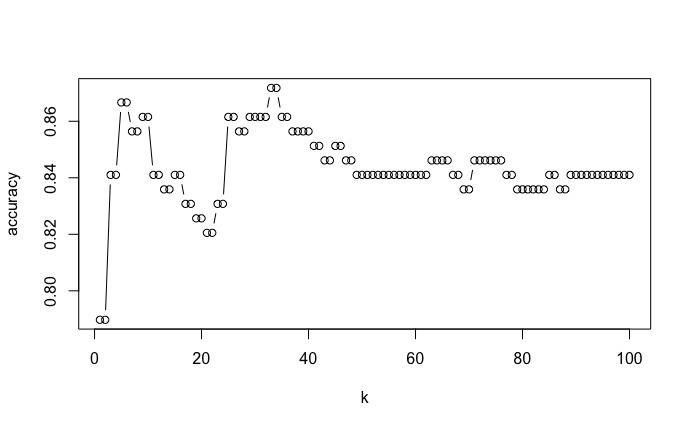

```r
plot(results,type = "b")
```

```r
#grab the best K value with the highest accuracy from results

best_k <- results[which.max(results$accuracy),]
print(best_k)
```

|  | k | accuracy |
| --- | --- | --- |
| 33 | 33 | 0.8717949 |

```r
#KNN Model training using k=33
dataKNN <- kknn(R1~.,trainData,testData, k = 33, scale = TRUE, kernel = "rectangular" )

k10_predictions <- predict(dataKNN)

accuracy <- sum(k10_predictions == testData$R1)/ nrow(testData)

print(accuracy)
```

```
[1] 0.8717949
```

Question 3.1 Using the same data set (credit_card_data.txt or credit_card_data-headers.txt) as in Question 2.2, use the ksvm or kknn function to find a good classifier: (a) using cross-validation(do this for the k-nearest-neighbors model;SVM is optional);and (b) splitting the data into training,validation,and test datasets(pick either KNN or SVM;the other is optional).

Part A: using cross-validation(do this for the k-nearest-neighbors model;SVM is optional)

Step 1: train KNN model using cross-validation (caret library)

```r
#set up parameters for train function

train_control <- trainControl(method = "cv", number = 10) #cross-validation method, using 10-fold                                                              number of evaluations Sokol lecture 3.4

tune_Grid <- expand.grid(kmax = 1:100, distance = 2, kernel = "rectangular") #kernel set to rectangular for simple fraction , k max value for finding optimal k for KNN was 1-->100, euclidian distance of 2


##### Train (caret function) KNN model using cross-validation (CV)
set.seed(100)
knn_model_CV <- train(R1~., data = trainData,
                      method = "kknn",
                      preProcess = c("center","scale"), #scale the data
                      trControl = train_control, #10-fold CV
                      tuneGrid = tune_Grid) #hyperparameters

print(knn_model_CV)
```

```
k-Nearest Neighbors

459 samples
 10 predictor
  2 classes: '0', '1'

Pre-processing: centered (10), scaled (10)
Resampling: Cross-Validated (10 fold)
Summary of sample sizes: 413, 413, 413, 413, 413, 413, ...
Resampling results across tuning parameters:

  kmax  Accuracy   Kappa
    1   0.8014791  0.5977388
    2   0.8014791  0.5977388
    3   0.8386772  0.6748601
```

[output cut: 103 more lines]

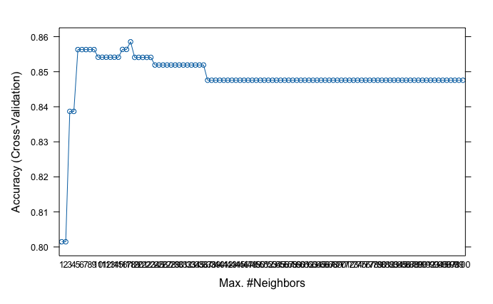

```r
plot(knn_model_CV, plotType = "line", auto.key = TRUE)
```

Step 2: Test best picked KNN model using cross-validation (caret library) on test dataset

```r
#### Testing CV model on test dataset

knn_model_CV_predict <- predict(knn_model_CV, testData)
accuracy_model_CV <- sum(knn_model_CV_predict == testData$R1)/ nrow(testData)

print(paste(" model accuracy on test data is", accuracy_model_CV))
```

```
[1] " model accuracy on test data is 0.866666666666667"
```

Part B: splitting the data into training,validation,and test datasets (pick either KNN or SVM;the other is optional).

Step 1: Split data into 3, training set, validation set and test set

```r
#split the data into training and test sets for knn using caret's createDataPartition function

set.seed(100) #for reproducible results


trainIndex <- createDataPartition(data$R1,
                                  times=1,
                                  p = .7,    # 70% of the data will be for training, remaining 30% will be leftover data
                                  list = FALSE)
trainDataPartB <- data[trainIndex, ]
leftoverDataPartB <- data[-trainIndex, ] #this 'leftover' data will be split 50;50 into validation and test sets

validationIndex <- createDataPartition(leftoverDataPartB$R1, p = 0.5, list = FALSE)
validation_data <- leftoverDataPartB[validationIndex,]
test_dataPartB <- leftoverDataPartB[-validationIndex,]
```

Step 2: Train a knn model using the training set and testing it on the validation set to get the best k value

```r
###### Train KNN model on training data with a loop going over diff k's

set.seed(100)

k_valuesPartB <- 1:100
resultsPartB <- data.frame(k = integer (), accuracy = numeric())

for (k in k_valuesPartB){
  modelPartB <- kknn(R1~., train = trainDataPartB, test = validation_data, k = k, distance = 2, kernel = "rectangular", scale = TRUE)
  predictPartB <- predict(modelPartB)
  accuracyPartB <- sum(predictPartB == validation_data$R1)/ nrow(validation_data)

   print(paste("K is ", k, "With an accuracy of", accuracyPartB))

  resultsPartB <- rbind(resultsPartB,data.frame(k = k, accuracy = accuracyPartB))


}
```

```
[1] "K is  1 With an accuracy of 0.76530612244898"
[1] "K is  2 With an accuracy of 0.76530612244898"
[1] "K is  3 With an accuracy of 0.846938775510204"
[1] "K is  4 With an accuracy of 0.846938775510204"
[1] "K is  5 With an accuracy of 0.897959183673469"
[1] "K is  6 With an accuracy of 0.897959183673469"
[1] "K is  7 With an accuracy of 0.887755102040816"
[1] "K is  8 With an accuracy of 0.887755102040816"
[1] "K is  9 With an accuracy of 0.877551020408163"
[1] "K is  10 With an accuracy of 0.877551020408163"
[1] "K is  11 With an accuracy of 0.846938775510204"
[1] "K is  12 With an accuracy of 0.846938775510204"
[1] "K is  13 With an accuracy of 0.857142857142857"
[1] "K is  14 With an accuracy of 0.857142857142857"
[1] "K is  15 With an accuracy of 0.857142857142857"
```

[output cut: 85 more lines]

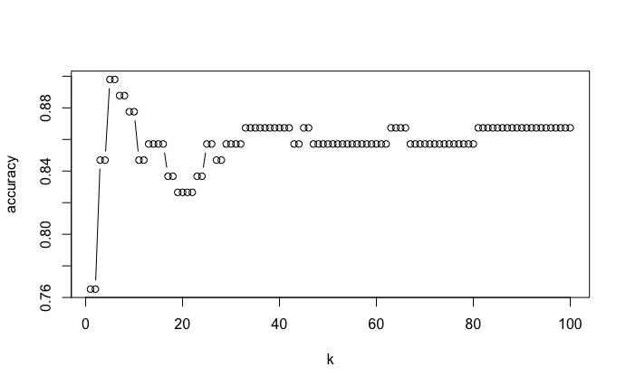

```r
plot(resultsPartB,type = "b")
```

Continuation of Step 2: Obtaining best k value (k=5) (accuracy obtained 89%)

```r
#### Best model selection for Part B

best_k_model_PartB <- resultsPartB[which.max(resultsPartB$accuracy),]
print(best_k_model_PartB)
```

|  | k | accuracy |
| --- | --- | --- |
| 5 | 5 | 0.8979592 |

```r
NA
NA
```

Step 3 test k=5 (best model) on Test dataset

```r
#### Test best k (k=5) obtained from validation data and test on test dataset

k5_model_PartB <- kknn(R1~., train = trainDataPartB, test = test_dataPartB, k = 5, distance = 2,
                         kernel = "rectangular", scale = TRUE)

k5_predictions <- predict(k5_model_PartB)


accuracy_PartB<- sum(k5_predictions == test_dataPartB$R1)/ nrow(test_dataPartB)

print(accuracy_PartB)
```

```
[1] 0.8350515
```

Final accuracy prediction is 0.8350515